# p8105_hw1_yy3295

Ye Yuan

2023-09-23

#Problem 1 The purpose of problem 1 is to focus on the use of inline R code, plotting, and the behavior of ggplot for variables of different types

```r
library(moderndive)
```

# Load the early_January_weather data set

```r
data("early_january_weather")
```

# The variables in the data set (names/variables of important variables)

# The mean temperature

```r
colnames(early_january_weather)
```

```
##  [1] "origin"     "year"       "month"      "day"        "hour"
##  [6] "temp"       "dewp"       "humid"      "wind_dir"   "wind_speed"
## [11] "wind_gust"  "precip"     "pressure"   "visib"      "time_hour"
```

```r
nrow(early_january_weather)
```

```
## [1] 358
```

```r
ncol(early_january_weather)
```

```
## [1] 15
```

```r
mean(early_january_weather$temp)
```

```
## [1] 39.58212
```

The variables are listed above. There are 358 observations and 15 variables in this data set. The mean temperature is 39.58 Fahrenheit.

# The scatter plot of temp (y) vs time_hour (x)

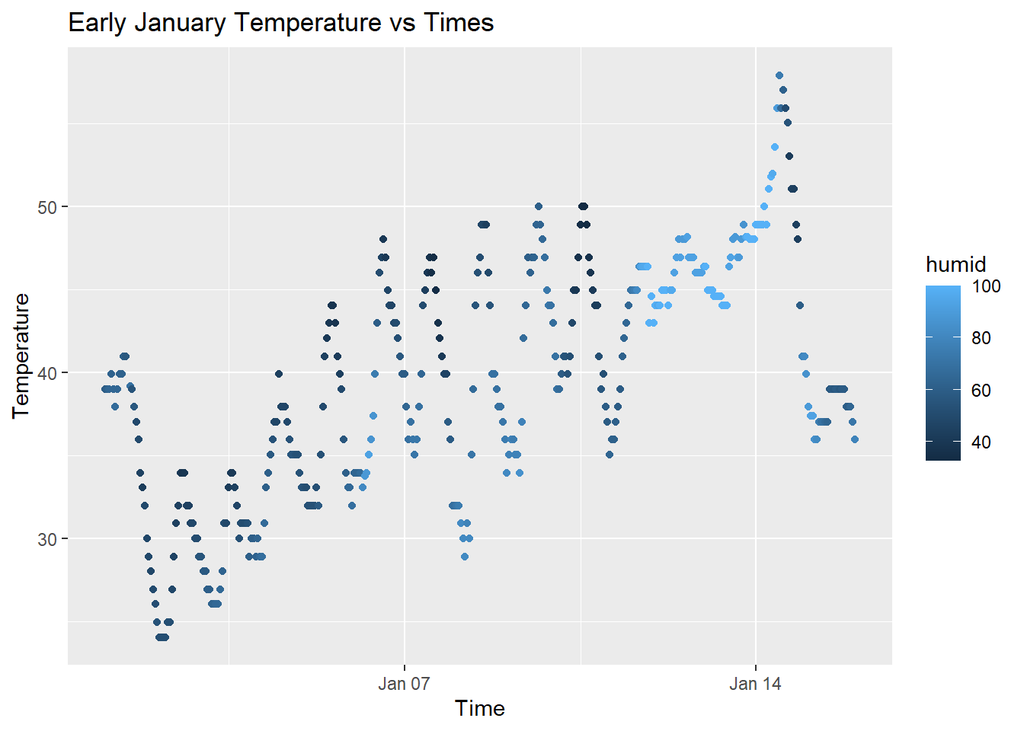

```r
ggplot(data = early_january_weather,
          mapping = aes(x = time_hour, y = temp, color = humid)) +
          geom_point() +
          labs(title = "Early January Temperature vs Times",
               y = "Temperature", x = "Time")
```

```r
ggsave("Early_January_Temp_Time.pdf")
```

# Problem 2

The purpose of problem 2 is to emphasize variable types and introduce coercion.

# Create dataframe with random sample, logical vector, character vector, and factor vector.

# Calculate the means

```r
DataFrame <- tibble(
  RandomSample = rnorm(10),
  LogicalVector = rnorm(10) > 0,
  CharacterVector = c("I", "II", "III", "IV", "V", "VI", "VII", "VIII", "IX", "X"),
  FactorVector = c("T1", "T1", "T1", "T2", "T2", "T2", "T3", "T3", "T3", "T3")
)

mean(DataFrame$RandomSample)
```

```
## [1] -0.1809853
```

```r
mean(DataFrame$LogicalVector)
```

```
## [1] 0.6
```

```r
mean(DataFrame$CharacterVector)
```

```
## [1] NA
```

```r
mean(DataFrame$FactorVector)
```

```
## [1] NA
```

```r
as.numeric(DataFrame$LogicalVector)
```

```
##  [1] 0 1 1 0 1 1 0 1 0 1
```

```r
as.numeric(DataFrame$CharacterVector)
```

```
##  [1] NA NA NA NA NA NA NA NA NA NA
```

```r
as.numeric(DataFrame$FactorVector)
```

```
##  [1] NA NA NA NA NA NA NA NA NA NA
```

We can take the mean of “Random Sample” and “Logical Vector” since they are numeric values. We cannot take the mean of “Character Vector” and “Factor Vector” since they are not numeric values.

When applied the “as.numeric” function, We can take the mean of “Random Sample” and “Logical Vector” since they are numeric values. However, We cannot take the mean of “Character Vector” and “Factor Vector” since they are not numeric values.